# Tutorial - Bayesian Regression

Ryan Mitchell

2022-10-03

## Topics

- Get a brief introduction to Bayesian statistics and understand how it differs from the frequentist point of view.
- Understand the difference between a credible interval and a confidence interval, particularly in how they can be interpreted.
- Understand how to create a Bayesian simple linear regression model with the `brms` package using different priors.

## 1. Installations and Data

This tutorial will make use of the following R libraries.

```r
library(dplyr)
library(brms)
library(knitr)
library(ggplot2)
```

This tutorial will be using the `nhanes` dataset where the variables are described in the file `nhanes-codebook.txt`. This data can be loaded with the `load` function, specifying the rda data file.

```r
load(file = 'nhanes1518.rda')
```

## 2. Introduction to Bayesian Statistics

There are two schools of thought in the world of statistics: frequentist, which we have been working with up to this point, and Bayesian. In the frequentist school, probability is defined as a frequency. For example, if we roll a fair six-sided die, the probability we will roll a 1 is $P(Y = 1) = \frac{1}{6}$. The conclusions we make in frequentist statistics are based on likelihood; we retrieve data and then make an inference based on the data.

In the Bayesian school, probability is defined as a belief. For example, a Bayesian statement could be “I believe the probability that it rains tomorrow is 30%.” Different people obviously have different beliefs, so another statistician stating “I believe the probability that it rains tomorrow is 40%” is just as valid. Like frequentist statistics, our conclusions rely on likelihood. However, unlike frequentists statistics, our conclusions also rely on another factor: our prior knowledge. When we collect data, we then use it to update our prior knowledge. For simplicity, we can simply refer to our prior knowledge that we wish to update as the **prior**. After we see our data, we update our prior to create the **posterior**.

But how exactly do we get from the prior to the posterior?

Bayesian statistics mostly deals with conditional probabilities, which can be calculated using the fittingly-named **Bayes’ rule**. Given two events A and B, the probability of event A conditional on event B as stated by Bayes’ rule is $P(A | B) = \frac{P(B | A)P(A)}{P(B)}$.

For example, we can use the Bayes’ rule with our `nhanes` dataset to calculate the probability that a subject in the dataset is female given their reported concentration of Mono(carboxynonyl) phthalate is above 10 ng/mL. For simplicity, we will only consider subjects with data points present for both the `RIAGENDR` and `URXCNP` variables, which deal with gender and Mono(carboxynonyl) phthalate concentration, respectively.

```r
bayesrule_ex <- nhanes1518 %>%
  filter(!is.na(RIAGENDR) & !is.na(URXCNP))
```

Let $F$ be the event in which a subject in the dataset is female, and let $M$ be the event in which a subject’s concentration of Mono(carboxynonyl) phthalate is above 10 ng/mL. Then, to find $P(F | M)$, we need to calculate $P(F)$, $P(M)$, and $P(M | F)$.

```r
female <- bayesrule_ex %>% filter(RIAGENDR == 2)
high_concentration <- bayesrule_ex %>% filter(URXCNP > 10)
female_and_high_concentration <- female %>% filter(URXCNP > 10)

p_f = nrow(female) / nrow(bayesrule_ex)
p_m = nrow(high_concentration) / nrow(bayesrule_ex)
p_m_given_f = nrow(female_and_high_concentration) / nrow(female)
```

We can then calculate $P(F | M)$ using Bayes’ rule; we can confirm this value is correct by also calculating $P(F | M)$ using row counts.

```r
p_f_given_m_bayes = p_m_given_f * p_f / p_m
p_f_given_m_bayes
```

```
## [1] 0.4672489
```

```r
p_f_given_m_rowcounts = nrow(female_and_high_concentration) / nrow(high_concentration)
p_f_given_m_rowcounts
```

```
## [1] 0.4672489
```

We get that, given a subject’s reported concentration of Mono(carboxynonyl) phthalate is above 10 ng/mL, the probability they will be female is approximately 46.7%.

## 3. Credible Intervals

When conducting hypothesis tests or linear regressions using the frequentist approach, we often find it useful to create a **confidence interval**. Confidence intervals help us estimate the (un)certainty of a parameter with a lower and upper bound. For example, let’s say we created a 95% confidence interval for the mean age in our dataset and found the lower bound to be 32 and the upper bound to be 47. We could then interpret this confidence interval as “We are 95% confident that the true mean age is between 32 and 47 years old.” If we constructed many more similar confidence intervals, we would expect 95% of them to contain the true population mean.

The Bayesian equivalent to a confidence interval is known as a **credible interval**, which has a simpler interpretation. For example, a 95% credible interval is between any lower bound $L$ and any upper bound $U$ such that the posterior probability of $L < p < U = 0.95$. This means that if we found the 95% credible interval for the mean age in our dataset to have a lower bound of 32 and an upper bound of 47, then we can simply say that “There is a 95% probability that the true mean age is between 32 and 47 years old.”

## 4. Bayesian Simple Linear Regression

In the previous unit, we discussed **linear regression**, which uses point estimates for parameters $\beta_0$ and $\beta_1$ in order to help predict the value of a dependent variable based on an independent variable. The formula for **Bayesian regression** may appear to be the same, but now, our parameters are drawn from probability distributions.

In the previous module, we used the `nhanes` dataset to fit a linear model predicting age, or `RIDAGEYR`, based on body mass index, or `BMXBMI`, using the frequentist approach. In this section, we will use the Bayesian approach to formulate the same model. Before we begin, we will limit our analysis to adults as we did in the previous module:

```r
nhanes1518 <- nhanes1518 %>%
  filter(RIDAGEYR >= 18)
```

Let’s visualize the distribution of the `BMXBMI` variable in our dataset:

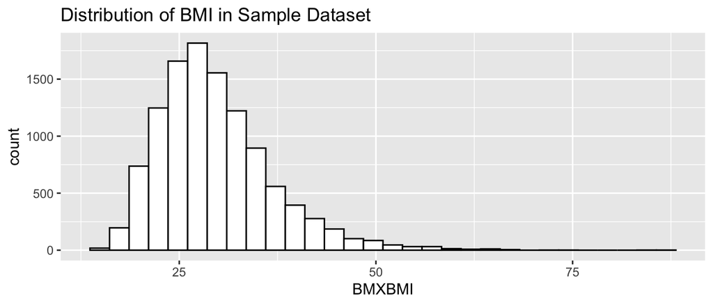

```r
ggplot(nhanes1518, aes(x = BMXBMI)) +
  geom_histogram(color = "black", fill = "white") +
  labs(title = 'Distribution of BMI in Sample Dataset')
```

We will use the `brms` library to create our Bayesian model. An important part of creating a Bayesian regression model is establishing our priors for the parameters. Based on our prior knowledge of the data, there is a variety of priors we can set (and thus a variety of models we can create). This module will introduce multiple different priors.

Firstly, assuming we have no prior knowledge of the data, we will use a noninformative prior (the default prior in `brms`). We can use the `brm` function to create our model.

```r
model1 <- brm(formula = RIDAGEYR ~ BMXBMI,
             data    = nhanes1518,
             seed    = 123)
```

We can use the `summary()` function to view more detailed statistics of our model.

```r
summary(model1, priors = TRUE)
```

```
##  Family: gaussian
##   Links: mu = identity; sigma = identity
## Formula: RIDAGEYR ~ BMXBMI
##    Data: nhanes1518 (Number of observations: 11096)
##   Draws: 4 chains, each with iter = 2000; warmup = 1000; thin = 1;
##          total post-warmup draws = 4000
##
## Priors:
## Intercept ~ student_t(3, 49, 22.2)
## <lower=0> sigma ~ student_t(3, 0, 22.2)
##
## Population-Level Effects:
##           Estimate Est.Error l-95% CI u-95% CI Rhat Bulk_ESS Tail_ESS
## Intercept    45.41      0.75    43.94    46.87 1.00     3704     2924
## BMXBMI        0.12      0.02     0.07     0.16 1.00     3760     2922
##
## Family Specific Parameters:
##       Estimate Est.Error l-95% CI u-95% CI Rhat Bulk_ESS Tail_ESS
## sigma    18.48      0.12    18.24    18.72 1.00     5156     2541
##
## Draws were sampled using sampling(NUTS). For each parameter, Bulk_ESS
## and Tail_ESS are effective sample size measures, and Rhat is the potential
## scale reduction factor on split chains (at convergence, Rhat = 1).
```

From this model, we get the same estimate for the intercept (45.41) and for the $\beta_{BMI}$ (0.12) as we got in our frequentist model. However, since we are now using a Bayesian approach, we can interpret our credible interval to mean that there is a 95% chance that the true value for the intercept lies between 43.94 and 46.87, and there is a 95% chance that the true value for $\beta_{BMI}$ lies between 0.07 and 0.16.

### Beta Priors: The Normal Distribution

A common prior for the coefficient (or $\beta$) in Bayesian inference deals with a **normal (Gaussian) distribution**. This is a **conjugate** prior, meaning that the posterior will also be a normal distribution, but with different parameters. This might be a good choice for our beta prior if we assume our data is normally distributed, meaning most values are situated in the middle, and there is a symmetrical decline in the frequency of values as we reach the ends.

```r
model2 <- brm(formula = RIDAGEYR ~ BMXBMI,
             data    = nhanes1518,
             prior   = c(set_prior("normal(0, 0.3)", class = "b", coef = "BMXBMI")),
             seed    = 123)
```

```r
summary(model2, priors = TRUE)
```

```
##  Family: gaussian
##   Links: mu = identity; sigma = identity
## Formula: RIDAGEYR ~ BMXBMI
##    Data: nhanes1518 (Number of observations: 11096)
##   Draws: 4 chains, each with iter = 2000; warmup = 1000; thin = 1;
##          total post-warmup draws = 4000
##
## Priors:
## b_BMXBMI ~ normal(0, 0.3)
## Intercept ~ student_t(3, 49, 22.2)
## <lower=0> sigma ~ student_t(3, 0, 22.2)
##
## Population-Level Effects:
##           Estimate Est.Error l-95% CI u-95% CI Rhat Bulk_ESS Tail_ESS
## Intercept    45.43      0.73    43.97    46.86 1.00     4875     3054
## BMXBMI        0.11      0.02     0.07     0.16 1.00     4964     3025
##
## Family Specific Parameters:
##       Estimate Est.Error l-95% CI u-95% CI Rhat Bulk_ESS Tail_ESS
## sigma    18.48      0.12    18.24    18.72 1.00     6102     3242
##
## Draws were sampled using sampling(NUTS). For each parameter, Bulk_ESS
## and Tail_ESS are effective sample size measures, and Rhat is the potential
## scale reduction factor on split chains (at convergence, Rhat = 1).
```

As we see from the summary, the estimates for the intercept and $\beta_{BMI}$ have changed slightly from our previous model, demonstrating how different priors can yield different results.

Let’s run another model with a normally distributed Beta prior, using the same mean but inputting a much larger variance:

```r
model3 <- brm(formula = RIDAGEYR ~ BMXBMI,
             data    = nhanes1518,
             prior   = c(set_prior("normal(0, 100)", class = "b", coef = "BMXBMI")),
             seed    = 123)
```

```r
summary(model3, priors = TRUE)
```

```
##  Family: gaussian
##   Links: mu = identity; sigma = identity
## Formula: RIDAGEYR ~ BMXBMI
##    Data: nhanes1518 (Number of observations: 11096)
##   Draws: 4 chains, each with iter = 2000; warmup = 1000; thin = 1;
##          total post-warmup draws = 4000
##
## Priors:
## b_BMXBMI ~ normal(0, 100)
## Intercept ~ student_t(3, 49, 22.2)
## <lower=0> sigma ~ student_t(3, 0, 22.2)
##
## Population-Level Effects:
##           Estimate Est.Error l-95% CI u-95% CI Rhat Bulk_ESS Tail_ESS
## Intercept    45.41      0.73    44.01    46.84 1.00     4204     3475
## BMXBMI        0.12      0.02     0.07     0.16 1.00     4289     3465
##
## Family Specific Parameters:
##       Estimate Est.Error l-95% CI u-95% CI Rhat Bulk_ESS Tail_ESS
## sigma    18.48      0.13    18.23    18.73 1.00     5036     2942
##
## Draws were sampled using sampling(NUTS). For each parameter, Bulk_ESS
## and Tail_ESS are effective sample size measures, and Rhat is the potential
## scale reduction factor on split chains (at convergence, Rhat = 1).
```

Let’s recap the models we’ve created so far with their results:

| $\beta_{BMI}$ Distributions | Posterior Means | Intercepts |
| --- | --- | --- |
| Default | 0.12 | 45.41 |
| N(0, 0.09) | 0.11 | 45.43 |
| N(0, 10000) | 0.12 | 45.41 |

### Beta Priors: The T-Distribution

Another common prior for the coefficient in Bayesian inference deals with the **t-distribution**. This differs from the normal distribution in that the values are less clustered in the middle, giving it heavier tails on the ends. Using the t-distribution can offer more robust estimation; it is often used on smaller, approximately normal datasets (for example, when n < 30). For the purpose of this section, we will proceed using a t-distribution to estimate $\beta_{BMI}$.

We can change the shape of our t-distribution by altering the **degrees of freedom**; the more degrees of freedom we have, the more we will resemble a normal distribution (so, the less heavy the tail ends will be). Let’s fit a model with a beta prior distributed as a unit t-distribution with 3 degrees of freedom:

```r
model4 <- brm(formula = RIDAGEYR ~ BMXBMI,
             data    = nhanes1518,
             prior   = c(set_prior("student_t(3, 0, 1)", class = "b", coef = "BMXBMI")),
             seed    = 123)
```

```r
summary(model4, priors = TRUE)
```

```
##  Family: gaussian
##   Links: mu = identity; sigma = identity
## Formula: RIDAGEYR ~ BMXBMI
##    Data: nhanes1518 (Number of observations: 11096)
##   Draws: 4 chains, each with iter = 2000; warmup = 1000; thin = 1;
##          total post-warmup draws = 4000
##
## Priors:
## b_BMXBMI ~ student_t(3, 0, 1)
## Intercept ~ student_t(3, 49, 22.2)
## <lower=0> sigma ~ student_t(3, 0, 22.2)
##
## Population-Level Effects:
##           Estimate Est.Error l-95% CI u-95% CI Rhat Bulk_ESS Tail_ESS
## Intercept    45.42      0.75    43.93    46.86 1.00     3555     2482
## BMXBMI        0.11      0.02     0.07     0.16 1.00     3280     2572
##
## Family Specific Parameters:
##       Estimate Est.Error l-95% CI u-95% CI Rhat Bulk_ESS Tail_ESS
## sigma    18.48      0.12    18.24    18.71 1.00     5382     3291
##
## Draws were sampled using sampling(NUTS). For each parameter, Bulk_ESS
## and Tail_ESS are effective sample size measures, and Rhat is the potential
## scale reduction factor on split chains (at convergence, Rhat = 1).
```

Again, our model results resemble those we have previously calculated. For demonstrative purposes, let’s also run a model with more degrees of freedom (a more Gaussian-like distribution):

```r
model5 <- brm(formula = RIDAGEYR ~ BMXBMI,
             data    = nhanes1518,
             prior   = c(set_prior("student_t(10000, 0, 1)", class = "b", coef = "BMXBMI")),
             seed    = 123)
```

```r
summary(model5, priors = TRUE)
```

```
##  Family: gaussian
##   Links: mu = identity; sigma = identity
## Formula: RIDAGEYR ~ BMXBMI
##    Data: nhanes1518 (Number of observations: 11096)
##   Draws: 4 chains, each with iter = 2000; warmup = 1000; thin = 1;
##          total post-warmup draws = 4000
##
## Priors:
## b_BMXBMI ~ student_t(10000, 0, 1)
## Intercept ~ student_t(3, 49, 22.2)
## <lower=0> sigma ~ student_t(3, 0, 22.2)
##
## Population-Level Effects:
##           Estimate Est.Error l-95% CI u-95% CI Rhat Bulk_ESS Tail_ESS
## Intercept    45.38      0.73    43.94    46.80 1.00     3670     3032
## BMXBMI        0.12      0.02     0.07     0.16 1.00     3634     2910
##
## Family Specific Parameters:
##       Estimate Est.Error l-95% CI u-95% CI Rhat Bulk_ESS Tail_ESS
## sigma    18.48      0.13    18.23    18.73 1.00     4430     2573
##
## Draws were sampled using sampling(NUTS). For each parameter, Bulk_ESS
## and Tail_ESS are effective sample size measures, and Rhat is the potential
## scale reduction factor on split chains (at convergence, Rhat = 1).
```

And now let’s once again recap our models:

| $\beta_{BMI}$ Distributions | Posterior Means | Intercepts |
| --- | --- | --- |
| Default | 0.12 | 45.41 |
| N(0, 0.09) | 0.11 | 45.43 |
| N(0, 10000) | 0.12 | 45.41 |
| StudentT(3, 0, 1) | 0.11 | 45.42 |
| StudentT(10000, 0, 1) | 0.12 | 45.38 |

Upon selecting our priors and running our models, we can then use our posterior information to conduct further regression. Usually, regardless of the initial choice of prior, results will end up converging to the same posterior after many iterations.

### Beta Priors: A Closer Look

In the previous sections, we have discovered that, regardless of our choice of prior, we get virtually identical results for the posterior means and intercepts. To get a better understanding of how prior selection can impact our regression models, let’s take a small sample of our overarching `nhanes` dataset.

```r
set.seed(456)
nhanes1518_sample <- sample_n(nhanes1518, 30)
```

First, let’s visualize the distribution of the `BMXBMI` variable in our new dataset:

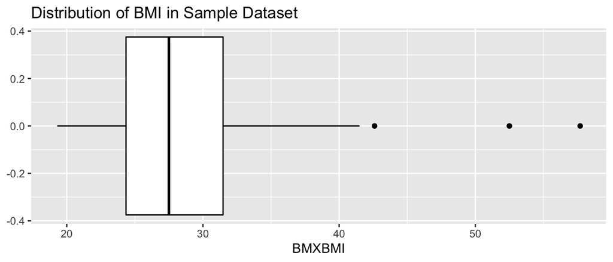

```r
ggplot(nhanes1518_sample, aes(x = BMXBMI)) +
  geom_boxplot(color = "black", fill = "white") +
  labs(title = 'Distribution of BMI in Sample Dataset')
```

Now, let’s rerun the five models we have examined so far with our updated dataset. We will recap our results in a summary table.

```r
model6 <- brm(formula = RIDAGEYR ~ BMXBMI,
             data    = nhanes1518_sample,
             seed    = 123)
```

```r
model7 <- brm(formula = RIDAGEYR ~ BMXBMI,
             data    = nhanes1518_sample,
             prior   = c(set_prior("normal(0, 0.3)", class = "b", coef = "BMXBMI")),
             seed    = 123)
```

```r
model8 <- brm(formula = RIDAGEYR ~ BMXBMI,
             data    = nhanes1518_sample,
             prior   = c(set_prior("normal(0, 100)", class = "b", coef = "BMXBMI")),
             seed    = 123)
```

```r
model9 <- brm(formula = RIDAGEYR ~ BMXBMI,
             data    = nhanes1518_sample,
             prior   = c(set_prior("student_t(3, 0, 1)", class = "b", coef = "BMXBMI")),
             seed    = 123)
```

```r
model10 <- brm(formula = RIDAGEYR ~ BMXBMI,
             data    = nhanes1518_sample,
             prior   = c(set_prior("student_t(10000, 0, 1)", class = "b", coef = "BMXBMI")),
             seed    = 123)
```

```r
summary(model6, priors = TRUE)
```

```
##  Family: gaussian
##   Links: mu = identity; sigma = identity
## Formula: RIDAGEYR ~ BMXBMI
##    Data: nhanes1518_sample (Number of observations: 26)
##   Draws: 4 chains, each with iter = 2000; warmup = 1000; thin = 1;
##          total post-warmup draws = 4000
##
## Priors:
## Intercept ~ student_t(3, 55.5, 24.5)
## <lower=0> sigma ~ student_t(3, 0, 24.5)
##
## Population-Level Effects:
##           Estimate Est.Error l-95% CI u-95% CI Rhat Bulk_ESS Tail_ESS
## Intercept    68.94     13.82    41.16    96.80 1.00     3204     2451
## BMXBMI       -0.51      0.44    -1.37     0.37 1.00     3117     2470
##
## Family Specific Parameters:
##       Estimate Est.Error l-95% CI u-95% CI Rhat Bulk_ESS Tail_ESS
## sigma    20.35      3.08    15.38    27.60 1.00     2976     2628
##
## Draws were sampled using sampling(NUTS). For each parameter, Bulk_ESS
## and Tail_ESS are effective sample size measures, and Rhat is the potential
## scale reduction factor on split chains (at convergence, Rhat = 1).
```

```r
summary(model7, priors = TRUE)
```

```
##  Family: gaussian
##   Links: mu = identity; sigma = identity
## Formula: RIDAGEYR ~ BMXBMI
##    Data: nhanes1518_sample (Number of observations: 26)
##   Draws: 4 chains, each with iter = 2000; warmup = 1000; thin = 1;
##          total post-warmup draws = 4000
##
## Priors:
## b_BMXBMI ~ normal(0, 0.3)
## Intercept ~ student_t(3, 55.5, 24.5)
## <lower=0> sigma ~ student_t(3, 0, 24.5)
##
## Population-Level Effects:
##           Estimate Est.Error l-95% CI u-95% CI Rhat Bulk_ESS Tail_ESS
## Intercept    58.90      8.47    42.44    75.45 1.00     3588     2910
## BMXBMI       -0.18      0.25    -0.65     0.30 1.00     3649     3052
##
## Family Specific Parameters:
##       Estimate Est.Error l-95% CI u-95% CI Rhat Bulk_ESS Tail_ESS
## sigma    20.33      3.07    15.47    27.32 1.00     3199     2401
##
## Draws were sampled using sampling(NUTS). For each parameter, Bulk_ESS
## and Tail_ESS are effective sample size measures, and Rhat is the potential
## scale reduction factor on split chains (at convergence, Rhat = 1).
```

```r
summary(model8, priors = TRUE)
```

```
##  Family: gaussian
##   Links: mu = identity; sigma = identity
## Formula: RIDAGEYR ~ BMXBMI
##    Data: nhanes1518_sample (Number of observations: 26)
##   Draws: 4 chains, each with iter = 2000; warmup = 1000; thin = 1;
##          total post-warmup draws = 4000
##
## Priors:
## b_BMXBMI ~ normal(0, 100)
## Intercept ~ student_t(3, 55.5, 24.5)
## <lower=0> sigma ~ student_t(3, 0, 24.5)
##
## Population-Level Effects:
##           Estimate Est.Error l-95% CI u-95% CI Rhat Bulk_ESS Tail_ESS
## Intercept    69.34     13.81    42.79    97.02 1.00     2722     2443
## BMXBMI       -0.52      0.44    -1.40     0.33 1.00     2806     2607
##
## Family Specific Parameters:
##       Estimate Est.Error l-95% CI u-95% CI Rhat Bulk_ESS Tail_ESS
## sigma    20.44      3.17    15.31    27.58 1.00     2933     2735
##
## Draws were sampled using sampling(NUTS). For each parameter, Bulk_ESS
## and Tail_ESS are effective sample size measures, and Rhat is the potential
## scale reduction factor on split chains (at convergence, Rhat = 1).
```

```r
summary(model9, priors = TRUE)
```

```
##  Family: gaussian
##   Links: mu = identity; sigma = identity
## Formula: RIDAGEYR ~ BMXBMI
##    Data: nhanes1518_sample (Number of observations: 26)
##   Draws: 4 chains, each with iter = 2000; warmup = 1000; thin = 1;
##          total post-warmup draws = 4000
##
## Priors:
## b_BMXBMI ~ student_t(3, 0, 1)
## Intercept ~ student_t(3, 55.5, 24.5)
## <lower=0> sigma ~ student_t(3, 0, 24.5)
##
## Population-Level Effects:
##           Estimate Est.Error l-95% CI u-95% CI Rhat Bulk_ESS Tail_ESS
## Intercept    66.05     12.84    41.45    90.99 1.00     3343     2717
## BMXBMI       -0.42      0.40    -1.19     0.36 1.00     3288     2132
##
## Family Specific Parameters:
##       Estimate Est.Error l-95% CI u-95% CI Rhat Bulk_ESS Tail_ESS
## sigma    20.31      3.06    15.43    27.38 1.00     3147     2644
##
## Draws were sampled using sampling(NUTS). For each parameter, Bulk_ESS
## and Tail_ESS are effective sample size measures, and Rhat is the potential
## scale reduction factor on split chains (at convergence, Rhat = 1).
```

```r
summary(model10, priors = TRUE)
```

```
##  Family: gaussian
##   Links: mu = identity; sigma = identity
## Formula: RIDAGEYR ~ BMXBMI
##    Data: nhanes1518_sample (Number of observations: 26)
##   Draws: 4 chains, each with iter = 2000; warmup = 1000; thin = 1;
##          total post-warmup draws = 4000
##
## Priors:
## b_BMXBMI ~ student_t(10000, 0, 1)
## Intercept ~ student_t(3, 55.5, 24.5)
## <lower=0> sigma ~ student_t(3, 0, 24.5)
##
## Population-Level Effects:
##           Estimate Est.Error l-95% CI u-95% CI Rhat Bulk_ESS Tail_ESS
## Intercept    66.94     12.83    41.48    92.28 1.00     3140     2117
## BMXBMI       -0.44      0.40    -1.24     0.35 1.00     3140     2386
##
## Family Specific Parameters:
##       Estimate Est.Error l-95% CI u-95% CI Rhat Bulk_ESS Tail_ESS
## sigma    20.37      3.15    15.38    27.46 1.00     2948     2422
##
## Draws were sampled using sampling(NUTS). For each parameter, Bulk_ESS
## and Tail_ESS are effective sample size measures, and Rhat is the potential
## scale reduction factor on split chains (at convergence, Rhat = 1).
```

[output not shown]

We now see notable differences in our posterior results.

### Variance Priors: The Inverse-Gamma

```r
model11 <- brm(formula = RIDAGEYR ~ BMXBMI,
             data    = nhanes1518_sample,
             prior   = c(set_prior("inv_gamma(3, 0.5)", class = "sigma")),
             seed    = 123)
```

```r
summary(model11, priors = TRUE)
```

```
##  Family: gaussian
##   Links: mu = identity; sigma = identity
## Formula: RIDAGEYR ~ BMXBMI
##    Data: nhanes1518_sample (Number of observations: 26)
##   Draws: 4 chains, each with iter = 2000; warmup = 1000; thin = 1;
##          total post-warmup draws = 4000
##
## Priors:
## Intercept ~ student_t(3, 55.5, 24.5)
## <lower=0> sigma ~ inv_gamma(3, 0.5)
##
## Population-Level Effects:
##           Estimate Est.Error l-95% CI u-95% CI Rhat Bulk_ESS Tail_ESS
## Intercept    69.41     12.66    44.19    94.45 1.00     2943     2406
## BMXBMI       -0.53      0.40    -1.31     0.28 1.00     2987     2456
##
## Family Specific Parameters:
##       Estimate Est.Error l-95% CI u-95% CI Rhat Bulk_ESS Tail_ESS
## sigma    18.96      2.67    14.63    25.00 1.00     3167     2945
##
## Draws were sampled using sampling(NUTS). For each parameter, Bulk_ESS
## and Tail_ESS are effective sample size measures, and Rhat is the potential
## scale reduction factor on split chains (at convergence, Rhat = 1).
```

```r
model12 <- brm(formula = RIDAGEYR ~ BMXBMI,
             data    = nhanes1518_sample,
             prior   = c(set_prior("inv_gamma(1, 1)", class = "sigma")),
             seed    = 123)
```

```r
summary(model12, priors = TRUE)
```

```
##  Family: gaussian
##   Links: mu = identity; sigma = identity
## Formula: RIDAGEYR ~ BMXBMI
##    Data: nhanes1518_sample (Number of observations: 26)
##   Draws: 4 chains, each with iter = 2000; warmup = 1000; thin = 1;
##          total post-warmup draws = 4000
##
## Priors:
## Intercept ~ student_t(3, 55.5, 24.5)
## <lower=0> sigma ~ inv_gamma(1, 1)
##
## Population-Level Effects:
##           Estimate Est.Error l-95% CI u-95% CI Rhat Bulk_ESS Tail_ESS
## Intercept    69.04     13.24    42.40    95.11 1.00     3773     2537
## BMXBMI       -0.51      0.41    -1.33     0.32 1.00     3834     2680
##
## Family Specific Parameters:
##       Estimate Est.Error l-95% CI u-95% CI Rhat Bulk_ESS Tail_ESS
## sigma    19.87      2.89    15.15    26.58 1.00     3355     2626
##
## Draws were sampled using sampling(NUTS). For each parameter, Bulk_ESS
## and Tail_ESS are effective sample size measures, and Rhat is the potential
## scale reduction factor on split chains (at convergence, Rhat = 1).
```

### Variance Priors: The Half-Cauchy Distribution

```r
model13 <- brm(formula = RIDAGEYR ~ BMXBMI,
             data    = nhanes1518_sample,
             prior   = c(set_prior("cauchy(0, 5)", class = "sigma")),
             seed    = 123)
```

```r
summary(model13, priors = TRUE)
```

```
##  Family: gaussian
##   Links: mu = identity; sigma = identity
## Formula: RIDAGEYR ~ BMXBMI
##    Data: nhanes1518_sample (Number of observations: 26)
##   Draws: 4 chains, each with iter = 2000; warmup = 1000; thin = 1;
##          total post-warmup draws = 4000
##
## Priors:
## Intercept ~ student_t(3, 55.5, 24.5)
## <lower=0> sigma ~ cauchy(0, 5)
##
## Population-Level Effects:
##           Estimate Est.Error l-95% CI u-95% CI Rhat Bulk_ESS Tail_ESS
## Intercept    69.10     13.39    42.56    96.11 1.00     3076     2750
## BMXBMI       -0.52      0.42    -1.36     0.31 1.00     3122     2697
##
## Family Specific Parameters:
##       Estimate Est.Error l-95% CI u-95% CI Rhat Bulk_ESS Tail_ESS
## sigma    19.82      2.92    15.06    26.50 1.00     3597     2809
##
## Draws were sampled using sampling(NUTS). For each parameter, Bulk_ESS
## and Tail_ESS are effective sample size measures, and Rhat is the potential
## scale reduction factor on split chains (at convergence, Rhat = 1).
```

introduce different priors– the prior we choose will be non-informative because we do not have any expertise yet. for conjugacy sometimes we use normal. second option is t distribution–people want this one because it has a heavy tail compared to normal, which can provide robust estimation. for sigma^2, people usually use inverse gamma distribution (also can consider uniform).

figure out how brms is defining inverse gamma and figure out what the mean is

dont try uniform for variance, but try half-cauchy (t with 1 degree of freedom)

let beta be normal (0, covariance matrix) with sigma following an inverse wishart distribution [for multivariate regression]

explore unit information prior? simpler prior for variance as opposed to wishart [for multivariate regression], but also question of what brms allows us to do

use uniform default prior for beta on the variance prior models

MULTIPLE REGRESSION: start with a flat normal on the betas and do something basic for sigma (set prior for each beta separate); give all predictors variance 1; have separate prior for the intercept (might give this one a bigger variance)

put all predictors on the same scale (scale function in r; subtracts the mean and divides by the standard deviation) – the priors for each beta are independent – normal prior with mean zero and biggish variance for each predictor; center intercept on 0 and variance of 500

inverse gamma: gamma where alpha*beta is the mean

get function to plot the posterior (maybe find a function to plot the prior?)

if cannot find in brms documentation, look in the STAN manual